# Factors Associated with Childhood Vaccination Coverage in Peru

Vanesa Silvera

2026-08-02

## Introduction

Childhood vaccination is one of the most effective public health interventions for preventing infectious diseases and reducing childhood morbidity and mortality. However, vaccination coverage may vary according to demographic, geographic, and socioeconomic characteristics.

This project analyzes childhood vaccination coverage in Peru using data from the Demographic and Health Survey. The analysis focuses on selected childhood vaccines and examines differences according to maternal education, household wealth, and place of residence.

## Research Question

How does childhood vaccination coverage vary according to maternal education, household wealth, and place of residence in Peru?

## Objective

The objective of this project is to analyze childhood vaccination coverage and explore differences according to selected maternal and household characteristics.

## Methods

### Data Source

This analysis uses data from the 2003 Peru Demographic and Health Survey (DHS), using the Women’s Individual Recode dataset. The analysis focuses on childhood vaccination and selected maternal and household characteristics, including maternal education, household wealth, and place of residence.

### Data Preparation

Variables related to childhood vaccination, maternal education, household wealth, and place of residence were selected for the analysis.

To facilitate the analysis of childhood vaccination, the dataset was reshaped from wide to long format so that each row represents one child. Child-specific variables, including date of birth, survival status, and vaccination history, were reorganized using a common child identifier.

The analysis was restricted to children aged 12 to 23 months. This age group was selected to assess coverage of the selected childhood vaccines included in this analysis: BCG, the third dose of DPT, the third dose of polio vaccine, and measles vaccination.

Vaccination status was recoded using the original DHS categories. Children with vaccination documented on the vaccination card or reported by the mother were classified as vaccinated. Children coded as not vaccinated were classified as unvaccinated, while unknown or missing responses were treated as missing values.

A combined vaccination indicator was created to identify children who had received all four selected vaccination components: BCG, DPT3, Polio3, and measles. Children were classified as having received the complete selected set only when information for all four vaccination variables was available.

Maternal education, household wealth, and place of residence were recoded into labelled categories to facilitate interpretation and comparison.

### Statistical Analysis

Descriptive analyses were conducted to characterize the study population and estimate vaccination coverage among children aged 12 to 23 months. Vaccination coverage was calculated for BCG, DPT3, Polio3, and measles. A combined indicator was also created to identify children who had received all four selected vaccines.

Vaccination coverage was compared according to maternal education, household wealth, and place of residence. Results were summarized using frequencies, percentages, means, medians, and interquartile ranges and were presented using tables and graphical visualizations. The analyses were descriptive and unweighted.

## Results

### Characteristics of the Study Population

The study population included 1,861 living children aged 12 to 23 months. Maternal education, household wealth, and place of residence were examined in relation to childhood vaccination coverage.

Table 1. Characteristics of the study population

| Characteristic | Category | n | Percent (%) |
| --- | --- | --- | --- |
| Maternal education | No education | 57 | 3.1 |
|  | Primary | 596 | 32.0 |
|  | Secondary | 804 | 43.2 |
|  | Higher | 404 | 21.7 |
| Place of residence | Urban | 1,072 | 57.6 |
|  | Rural | 789 | 42.4 |
| Household wealth | Poorest | 560 | 30.1 |
|  | Poorer | 498 | 26.8 |
|  | Middle | 386 | 20.7 |
|  | Richer | 252 | 13.5 |
|  | Richest | 165 | 8.9 |

Among the 1,861 children included in the study, 43.2% had mothers with secondary education, while 32.0% had mothers with primary education and 21.7% had mothers with higher education. Only 3.1% had mothers with no formal education. More than half of the children lived in urban areas (57.6%), compared with 42.4% in rural areas. Regarding household wealth, 30.1% of children belonged to the poorest wealth category and 26.8% to the poorer category, while 8.9% belonged to the richest category.

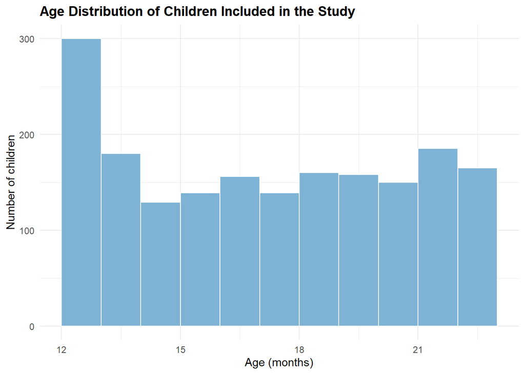

**Figure 1** shows the age distribution of the study population. Children were between 12 and 23 months of age, with observations distributed across the selected age range.

### Vaccination Coverage

Vaccination coverage was assessed for BCG, DPT3, Polio3, and measles among children aged 12 to 23 months.

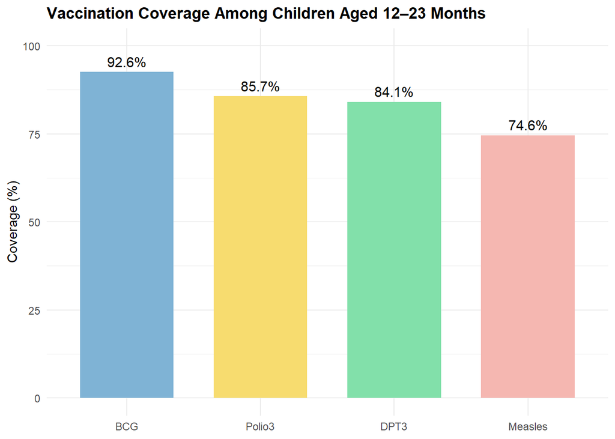

**Figure 2** shows differences in coverage across the four selected childhood vaccines. BCG had the highest coverage, with 92.6% of children vaccinated, followed by Polio3 (85.7%) and DPT3 (84.1%). Measles vaccination had the lowest coverage at 74.6%. These results suggest that coverage was higher for vaccines administered earlier in infancy, while measles vaccination showed a comparatively lower level of uptake among children aged 12 to 23 months.

### Coverage of All Four Selected Vaccines

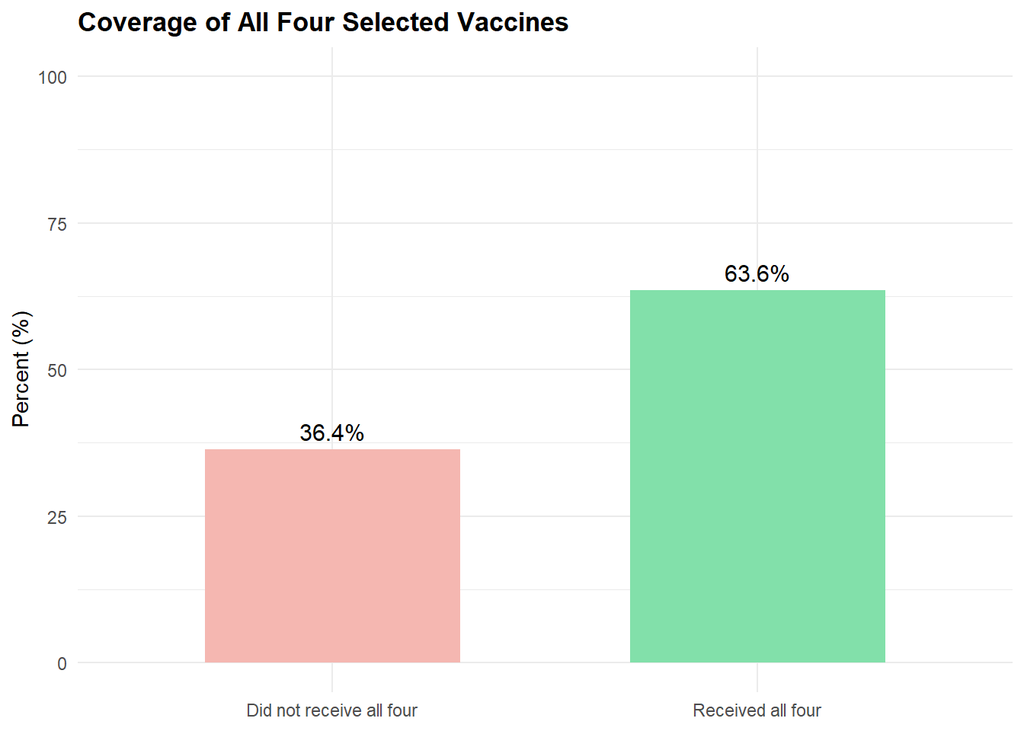

**Figure 3** shows the overall coverage of the four selected vaccination components. Among children with complete vaccination information, 63.6% had received all four selected components, while 36.4% had not received the complete set of BCG, DPT3, Polio3, and measles vaccination.

### Vaccination Coverage by Maternal Education

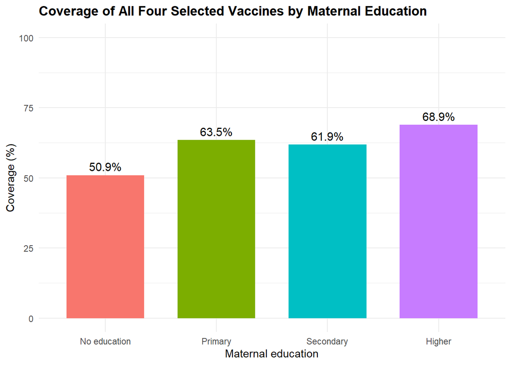

**Figure 4** shows that coverage of all four selected vaccines varied according to maternal education. The highest coverage was observed among children whose mothers had higher education (68.9%), while the lowest coverage was found among children whose mothers had no formal education (50.9%). Coverage was similar among children whose mothers had primary (63.5%) and secondary education (61.9%). Overall, the results suggest differences in vaccination coverage according to maternal educational level, although a consistent increasing gradient was not observed across all categories.

### Vaccination Coverage by Household Wealth

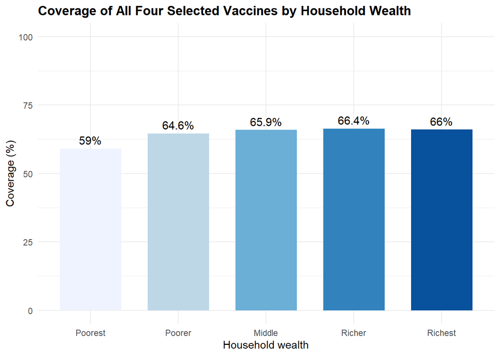

**Figure 5** shows differences in vaccination coverage across household wealth categories. Children in the poorest households had the lowest coverage (59.0%). Coverage increased to 64.6% among the poorer group and remained around 66% in the middle, richer, and richest categories. These findings suggest a socioeconomic difference in vaccination coverage, particularly between children from the poorest households and those from higher wealth groups.

### Vaccination Coverage by Place of Residence

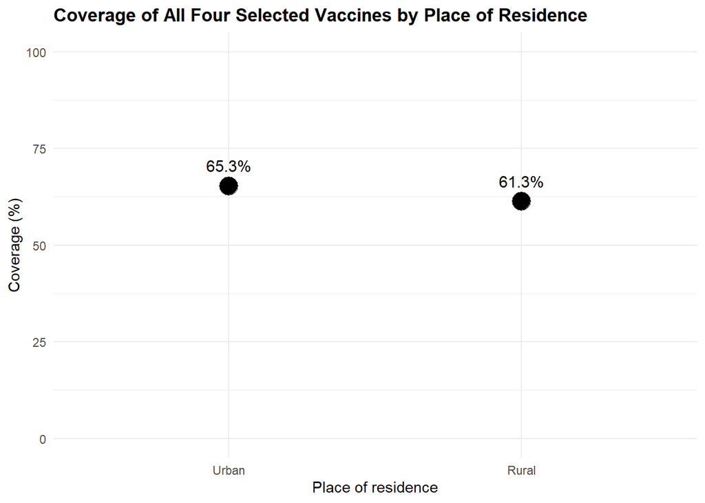

**Figure 6** shows a modest difference in coverage of all four selected vaccines by place of residence. Coverage was higher among children living in urban areas (65.3%) than among those living in rural areas (61.3%). This suggests a small urban–rural difference in vaccination coverage within the study population.

### Age and Vaccination Status

To explore whether vaccination status differed across the selected age range, age distributions were compared between children who had and had not received all four selected vaccines.

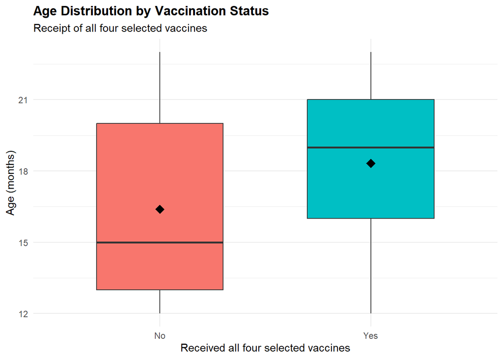

**Figure 7** shows differences in age distribution according to vaccination status. Children who had received all four selected vaccines were generally older, with a median age of 19 months and a mean age of 18.3 months, compared with a median of 15 months and a mean of 16.4 months among children who had not received all four vaccines. The interquartile range was 16–21 months among children who received all four vaccines and 13–20 months among those who did not. This pattern suggests that age within the 12–23 month range is relevant when interpreting the combined vaccination indicator, as older children have had more time to receive the selected vaccines.

## Discussion

This analysis identified differences in childhood vaccination coverage among children aged 12 to 23 months in Peru. Coverage varied across the four selected vaccination components, with BCG showing the highest coverage (92.6%), followed by Polio3 (85.7%) and DPT3 (84.1%), while measles vaccination showed the lowest coverage (74.6%). These differences may partly reflect the timing of vaccine administration in the Peruvian vaccination schedule in 2003. BCG was scheduled at birth, while the primary DPT and oral polio vaccine series were administered during the first months of life, and the measles-containing SPR vaccine was scheduled at 12 months of age. Therefore, children at the younger end of the 12–23 month age range had had less time to receive the vaccine scheduled at 12 months compared with vaccines administered earlier in infancy.

When the four selected vaccines were considered together, 63.6% of children with complete information had received BCG, DPT3, Polio3, and measles vaccination. This combined indicator should be interpreted as receipt of the four vaccines selected for this analysis rather than completion of the entire national childhood immunization schedule.

Differences in vaccination coverage were also observed according to maternal education. Children whose mothers had higher education showed the highest coverage of all four selected vaccines (68.9%), while children whose mothers had no formal education had the lowest coverage (50.9%). However, coverage did not increase consistently across all educational categories, since children whose mothers had primary education showed slightly higher coverage than those whose mothers had secondary education. Therefore, the results suggest differences according to maternal educational level, but not a clear linear educational gradient.

Household wealth showed a somewhat clearer socioeconomic pattern. Children from the poorest households had the lowest coverage (59.0%), while coverage was higher in the other wealth categories and remained around 66% among the middle, richer, and richest groups. This pattern suggests that socioeconomic conditions may be associated with differences in childhood vaccination coverage, particularly among children living in the poorest households.

A smaller difference was observed according to place of residence. Coverage of all four selected vaccines was 65.3% among children living in urban areas and 61.3% among those living in rural areas. Although the difference was modest, it suggests that place of residence may also be related to vaccination coverage in the study population.

Age was an important factor when interpreting the combined vaccination indicator. Children who had received all four selected vaccines were older, with a mean age of 18.3 months and a median age of 19 months, compared with a mean of 16.4 months and a median of 15 months among children who had not received all four vaccines. This finding supports the importance of considering the timing of vaccine administration when interpreting coverage among children aged 12 to 23 months. Older children have had more time to receive vaccines scheduled later in infancy, which may partly explain the observed difference in the combined vaccination indicator.

Overall, the findings suggest that childhood vaccination coverage in this population varied according to maternal education, household wealth, and place of residence. However, these differences should be interpreted together with the age distribution of the children and the timing of vaccine administration. Since this analysis is descriptive, the observed patterns should not be interpreted as evidence that maternal education, household wealth, or place of residence directly cause differences in vaccination coverage.

### Limitations

This analysis has several limitations. Vaccination status was based on information recorded on vaccination cards or reported by mothers, which may affect the accuracy of vaccination information. Unknown and missing responses were excluded from the corresponding coverage calculations.

The combined vaccination indicator included only BCG, DPT3, Polio3, and measles vaccination and therefore should not be interpreted as completion of the full childhood immunization schedule in Peru. In addition, age varied within the 12–23 month study population and was associated with receipt of all four selected vaccination components. This is particularly relevant because the measles-containing vaccine was scheduled at 12 months of age in the 2003 Peruvian vaccination schedule, while the other vaccination components analyzed were scheduled earlier in infancy.

Finally, the analysis was descriptive and unweighted and did not adjust for age or other potential confounding factors when comparing vaccination coverage across maternal education, household wealth, and place of residence.

## Conclusion

This analysis showed that vaccination coverage among children aged 12 to 23 months in Peru varied across the four selected vaccines and according to selected sociodemographic characteristics. BCG had the highest coverage, while measles vaccination had the lowest. Approximately two-thirds of children with complete vaccination information had received all four selected vaccines: BCG, DPT3, Polio3, and measles.

Differences were observed according to maternal education, household wealth, and place of residence. Coverage was lowest among children whose mothers had no formal education and among those living in the poorest households. Children living in urban areas also showed slightly higher coverage than those living in rural areas.

Age was important for interpreting these findings, as children who had received all four selected vaccines were generally older than those who had not. This highlights the importance of considering the timing of vaccine administration when assessing vaccination coverage within the 12–23 month age range.

Overall, the findings suggest that socioeconomic and demographic differences should be considered when examining childhood vaccination coverage.

## References

Ministerio de Salud del Perú. (2003). *Resolución Ministerial N.º 511-2003-SA/DM. Calendario de Vacunación del Perú 2003.*